# Assigment 1

Luis Mario Trevisi

2020-09-14

# 15/15

# Task 1

The Grading system in this class would be devided on 7 categories with different percentages:

```r
read.csv('ClassSummary.csv')
```

```
##        Category Number Percentage
## 1   Assignments      4        15%
## 2 Laboratories      16        10%
## 3      Projects      2        10%
## 4 In Class Quiz   TBD.        10%
## 5  Chapter Quiz   TBD.         5%
## 6  MidTerm Exam      1        20%
## 7         Final      1        30%
```

The grades would be determine by using the percentages above. there would not be curving. also, the grade cuts would be 90 and above for an A, 80 and above for a B, 60 and above for a C, 50 and above for a D, and the rest would be a F

# Task 2

```r
ddt = read.csv("C:\\Users\\Luis Mario Trevisi\\OneDrive - University of Oklahoma\\OU\\Applied Statistical Methods\\Math4753\\MATH4753ouTrev0002\\Laboratories\\Lab 1\\DDT.csv")
head(ddt)
```

```
##   RIVER MILE  SPECIES LENGTH WEIGHT DDT
## 1   FCM    5 CCATFISH   42.5    732  10
## 2   FCM    5 CCATFISH   44.0    795  16
## 3   FCM    5 CCATFISH   41.5    547  23
## 4   FCM    5 CCATFISH   39.0    465  21
## 5   FCM    5 CCATFISH   50.5   1252  50
## 6   FCM    5 CCATFISH   52.0   1255 150
```

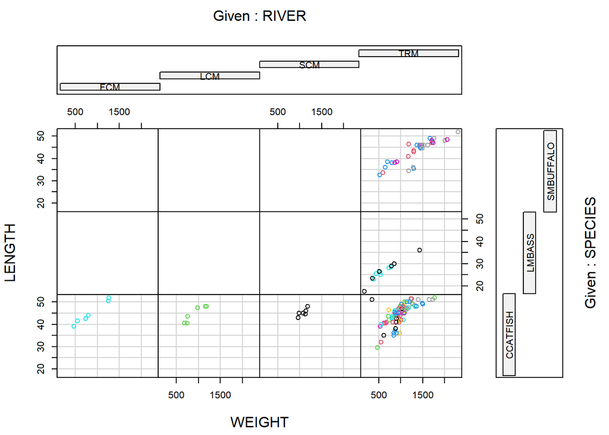

```r
coplot(LENGTH~WEIGHT|RIVER*SPECIES,data=ddt, col = ddt$MILE)
```

2. This represent the fishes of the species “CCATFISH” that where trap on the rivers “FCM”, “LCM” and “SCM” (left to rigth). the color of the dots also represent the the postions (miles) where the fished where caught. finally the x and why axes give the information about the weight and the length of the fish.
3. it creates a factor variable for each different mile length that was recorded. in this way we can see how many different mile numbers were reported. i.e it creates qualitative subgroups for the different types of miles that were reported.
4. it counts the total number of qualitative subgroups that were created on part A.
5. because “LMBASS” and “SMBUFFALO” were not caugth on the rivers “FCM”, “LCM” and “SCM”

```r
m = with(ddt, ddt[SPECIES == "CCATFISH" & RIVER=="FCM",])
mean(m$DDT)
```

```
## [1] 45
```

# Task 3

1. Quantitative
2. Quantitative
3. Qualitative
4. Quantitative
5. Qualitative
6. Quantitative
7. Qualitative

# task 4

1. Simple Random Sampling, Stratified random sampling, cluster sampling, systematic sampling

Simple Random Sampling: it is a method where every experimental unit and samples have the same chance of selection

Stratified random sampling: this is a method employed when the experimental units can be separated into groups of units. the experimental units would be more similar within the groups than across the groups

cluster sampling: in this method, natural groupings are sampled (called clusters) first and then data is collected for each experimental unit within the cluster

systematic sampling: this method consist on choosing and analyzing every nth experimental units

# Task 5

```r
mtbe=read.csv("C:\\Users\\Luis Mario Trevisi\\OneDrive - University of Oklahoma\\OU\\Applied Statistical Methods\\Math4753\\MATH4753ouTrev0002\\Assignment\\Assignment 1\\MTBE.csv", header=TRUE)
head(mtbe) # First six lines
```

```
##     pH SpConduct DissOxy RoadsPct IndPct UrbanPct DevPct WellClass Aquifier
## 1 7.87     290.0    0.58     1.34      0    17.77  17.77   Private  Bedrock
## 2 8.63     225.9    0.84     0.72      0    10.43  10.43   Private  Bedrock
## 3 7.11     157.4    8.37     1.92      0    29.62  50.01   Private  Bedrock
## 4 7.98     723.6    0.41     2.76      0    41.65  41.65   Private  Bedrock
## 5 7.88     148.7    1.44     3.51      0    51.21  51.21   Private  Bedrock
## 6 8.36     198.2    0.18     1.48      0    22.49  29.19   Private  Bedrock
##     Depth SafeYld Distance MTBE.Detect MTBE.Level HouseDen PopDen
## 1  60.960      NA  2386.29 Below Limit        0.2   131.16  43.19
## 2  36.576      NA  3667.69 Below Limit        0.2    47.69  24.52
## 3 152.400      NA  2324.15 Below Limit        0.2    85.16  33.32
## 4      NA      NA   788.88 Below Limit        0.2   134.77  46.61
## 5  91.440      NA  1337.88 Below Limit        0.2   198.54  78.58
## 6 115.824      NA  2396.74 Below Limit        0.2   206.73  59.47
```

```r
dim(mtbe) # rows and columns
```

```
## [1] 223  16
```

```r
ind=sample(1:223,5,replace=FALSE) # random indices
mtbe[ind,]
```

```
##       pH SpConduct DissOxy RoadsPct IndPct UrbanPct DevPct WellClass Aquifier
## 176 7.49     873.5    0.45     2.62   0.00    59.66  61.18    Public  Bedrock
## 206 8.07     272.3    0.50     1.64   0.00    13.53  66.28    Public  Bedrock
## 33  9.46     238.3    7.76     0.72   0.00     6.75   6.75   Private  Bedrock
## 114 7.58     399.7    1.74     2.73  18.35    40.83  40.83    Public  Bedrock
## 45  6.67     615.3    2.38     4.18   0.00    68.59  68.59   Private  Bedrock
##        Depth   SafeYld Distance MTBE.Detect MTBE.Level HouseDen PopDen
## 176  77.1144  37.85011  1114.43 Below Limit       0.20   553.21 146.58
## 206  43.8912        NA  1963.71 Below Limit       0.20    12.98   6.49
## 33  129.2352        NA  3060.33 Below Limit       0.20    23.52   7.13
## 114  99.0600 473.12642   130.48      Detect       3.10   150.51  56.71
## 45        NA        NA  2552.87      Detect       0.26   405.37 127.06
```

```r
mtbeo=na.omit(mtbe)
mtbeo
```

```
##       pH SpConduct DissOxy RoadsPct IndPct UrbanPct DevPct WellClass  Aquifier
## 104 7.43     663.2    0.56     2.26   0.00    27.42  27.42    Public Unconsoli
## 105 7.76     919.3    6.63    10.62  22.41    72.02  72.71    Public Unconsoli
## 106 7.01     409.9    5.94     1.58   0.84    20.88  20.88    Public Unconsoli
## 107 6.55     248.6    7.07     2.09   1.34    40.59  49.97    Public Unconsoli
## 108 7.91     223.0   10.60     4.10   6.54    43.08  43.08    Public Unconsoli
## 109 7.51     428.5    7.94     1.95   0.00    35.42  51.90    Public Unconsoli
## 110 7.70     558.1    1.43     1.92   0.00     8.24  22.54    Public Unconsoli
## 112 6.57     460.4    1.26     0.54   0.00     6.84  67.80    Public Unconsoli
## 113 7.64     483.0    0.35     5.40   0.00    56.33  56.33    Public   Bedrock
## 114 7.58     399.7    1.74     2.73  18.35    40.83  40.83    Public   Bedrock
## 115 7.87     225.1    5.22     1.42   0.00    18.63  18.63    Public   Bedrock
## 116 8.09     248.5    0.37     3.04  11.80    52.54  56.80    Public   Bedrock
## 117 7.90     516.6    0.40     3.42   1.91    66.43  71.67    Public   Bedrock
## 118 6.40     527.8    2.14     2.41   0.00    29.03  31.36    Public   Bedrock
```

[output cut: 177 more lines]

```r
depth=mtbeo[mtbeo$Aquifier=="Bedrock",]$Depth
sd(depth)
```

```
## [1] 56.45357
```

# Task 6

```r
earthquake=read.csv("C:\\Users\\Luis Mario Trevisi\\OneDrive - University of Oklahoma\\OU\\Applied Statistical Methods\\Math4753\\MATH4753ouTrev0002\\Assignment\\Assignment 1\\EARTHQUAKE.csv", header=TRUE)
#head(earthquake) # First six lines
#dim(earthquake) # rows and columns
ind=sample(1:2929,30,replace=FALSE) # random indices
earthquake[ind,]
```

```
##      YEAR MONTH DAY HOUR MINUTE MAGNITUDE
## 1844 1994     1  26   11     50       2.6
## 807  1994     1  21    0     38       2.7
## 397  1994     1  19    6     23       3.3
## 2220 1994     1  29    4     52       1.8
## 2128 1994     1  28   13     54       1.9
## 343  1994     1  18   21     14       3.1
## 2594 1994     2   3    3     13       2.2
## 1898 1994     1  26   20     34       1.6
## 1129 1994     1  22   11     46       2.1
## 2489 1994     2   2    4     18       1.7
## 2855 1994     2   5   12      7       1.6
## 1224 1994     1  22   22      4       2.2
## 2349 1994     1  31   14     21       1.8
## 558  1994     1  19   23     26       1.7
```

[output cut: 16 more lines]

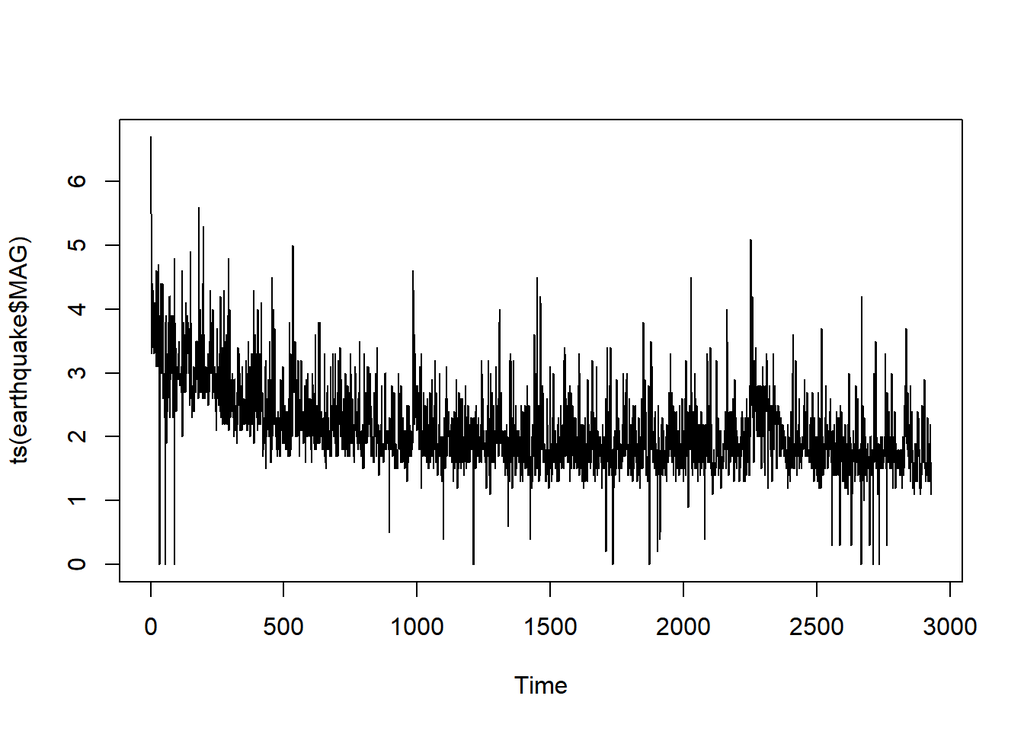

```r
plot(ts(earthquake$MAG))
```

ii)

```r
median(earthquake$MAGNITUDE)
```

```
## [1] 2
```

# Task 7

1. Stratified random sampling
2. All fish in the Tennessee River c)RIVER (location) and SPECIES

# Task 8

1. Bar Plot
2. Types of Robotic Limbs
3. Robots with robotic legs

```r
read.csv("C:\\Users\\Luis Mario Trevisi\\OneDrive - University of Oklahoma\\OU\\Applied Statistical Methods\\Math4753\\MATH4753ouTrev0002\\Assignment\\Assignment 1\\Robot.csv", header=TRUE)
```

```
##     None  Both   Legs Wheels
## 1 14.15% 7.55% 59.43% 18.87%
```

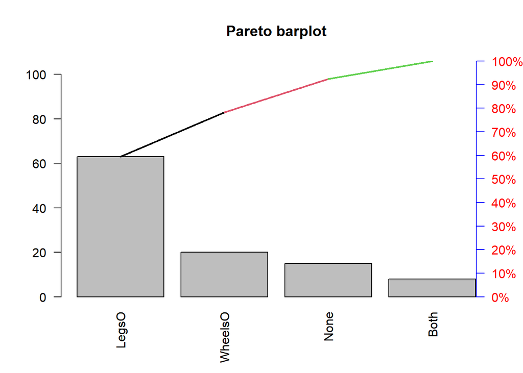

```r
pareto<-function(x,mn="Pareto barplot",...){  # x is a vector
x.tab=table(x)
xx.tab=sort(x.tab, decreasing=TRUE,index.return=FALSE)
cumsum(as.vector(xx.tab))->cs
length(x.tab)->lenx
bp<-barplot(xx.tab,ylim=c(0,max(cs)),las=2)
lb<-seq(0,cs[lenx],l=11)
axis(side=4,at=lb,labels=paste(seq(0,100,length=11),"%",sep=""),las=1,line=-1,col="Blue",col.axis="Red")
for(i in 1:(lenx-1)){
segments(bp[i],cs[i],bp[i+1],cs[i+1],col=i,lwd=2)
}
title(main=mn,...)

}

freq=c(15,8,63,20)
RL=c("None","Both","LegsO","WheelsO")
l=rep(RL,freq)
pareto(l)
```

# Task 9

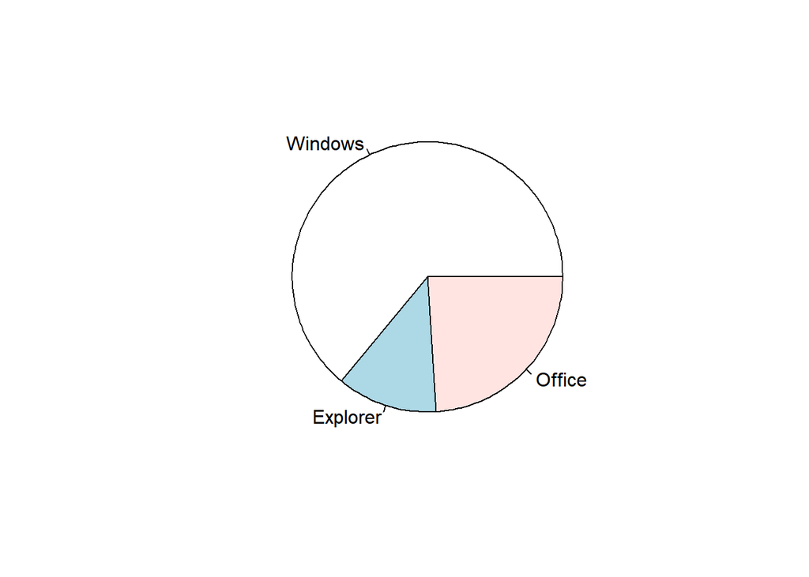

```r
freq=c(32,6,12)
RL=c("Windows","Explorer","Office")
pie(freq,RL)
```

b)

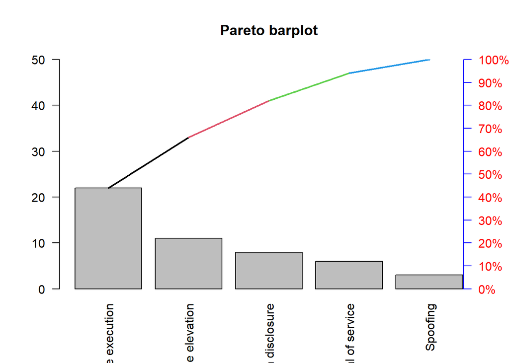

```r
freq=c(6, 8,22, 3, 11)
RL=c(" Denial of service","Information disclosure","Remote code execution"," Spoofing","Privilege elevation")
l=rep(RL,freq)
pareto(l)
```

# Task 10

```r
swd=read.csv("C:\\Users\\Luis Mario Trevisi\\OneDrive - University of Oklahoma\\OU\\Applied Statistical Methods\\Math4753\\MATH4753ouTrev0002\\Assignment\\Assignment 1\\SWDEFECTS.csv", header=TRUE)
head(swd)
```

```
##   Mloc Mvg Mevg Mivg   Hn  Hvol Hpgmlen Hdiff Hintell Heffort   Hb Htime Hloc
## 1  1.1 1.4  1.4  1.4  1.3   1.3    1.30  1.30    1.30       1 1.30     1    2
## 2  1.0 1.0  1.0  1.0  1.0   1.0    1.00  1.00    1.00       1 1.00     1    1
## 3 24.0 5.0  1.0  3.0 63.0 309.1    0.11  9.50   32.54    2937 0.10   163    1
## 4 20.0 4.0  4.0  2.0 47.0 215.5    0.06 16.00   13.47    3448 0.07   192    0
## 5 24.0 6.0  6.0  2.0 72.0 346.1    0.06 17.33   19.97    6000 0.12   333    0
## 6 24.0 6.0  6.0  2.0 72.0 346.1    0.06 17.33   19.97    6000 0.12   333    0
##   Hcomm Hblank loc.comm uniOp uniOpnd totOp totOpnd brnchcnt defect
## 1     2      2        2   1.2     1.2   1.2     1.2      1.4  FALSE
## 2     1      1        1   1.0     1.0   1.0     1.0      1.0   TRUE
## 3     0      6        0  15.0    15.0  44.0    19.0      9.0  FALSE
## 4     0      3        0  16.0     8.0  31.0    16.0      7.0  FALSE
## 5     0      3        0  16.0    12.0  46.0    26.0     11.0  FALSE
## 6     0      3        0  16.0    12.0  46.0    26.0     11.0  FALSE
##   predict.vg.10 predict.evg.14.5 predict.ivg.9.2 predict.loc.50
## 1            no               no              no             no
## 2            no               no              no             no
## 3            no               no              no             no
## 4            no               no              no             no
## 5            no               no              no             no
## 6            no               no              no             no
```

```r
library(plotrix)
tab=table(swd$defect)
rtab=tab/sum(tab)
round(rtab,2)
```

```
##
## FALSE  TRUE
##   0.9   0.1
```

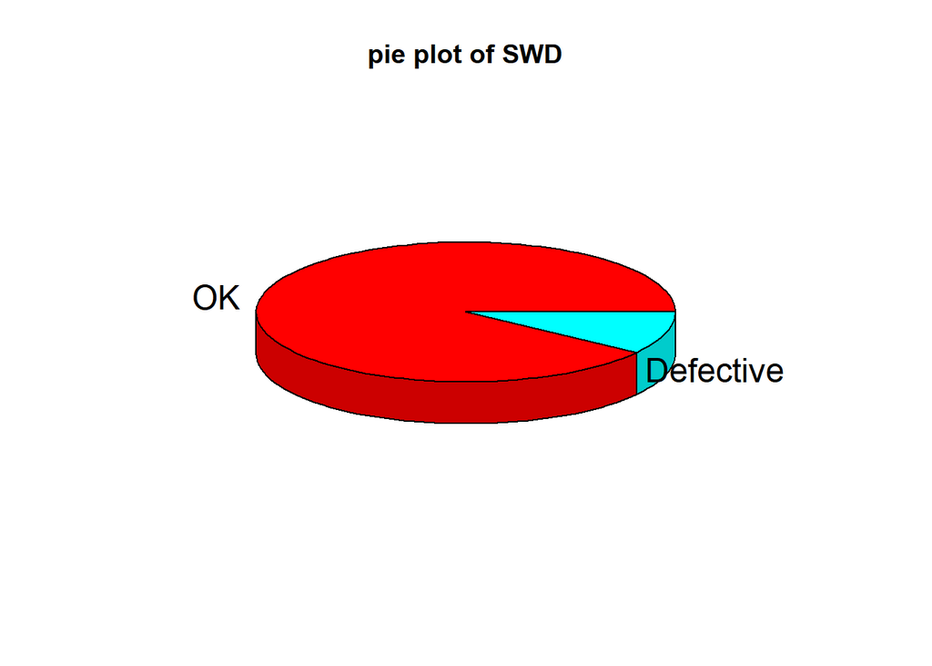

```r
pie3D(rtab,labels=list("OK","Defective"),main="pie plot of SWD")
```

It seems like around 10% of the code would be wrong, which is relatively small. thus, the likelyhood of getting a wrong code is small

# Task 11

```r
voltage.df=read.csv("C:\\Users\\Luis Mario Trevisi\\OneDrive - University of Oklahoma\\OU\\Applied Statistical Methods\\Math4753\\MATH4753ouTrev0002\\Assignment\\Assignment 1\\VOLTAGE.csv", header=TRUE)
old<-subset(voltage.df,subset=LOCATION=="OLD")
old$VOLTAGE->vtn
#vtn
#max(vtn)
#min(vtn)
lept<-min(vtn)-0.05
rept<-max(vtn)+0.05
rnge<-rept-lept
inc<-rnge/9
inc
```

```
## [1] 0.2888889
```

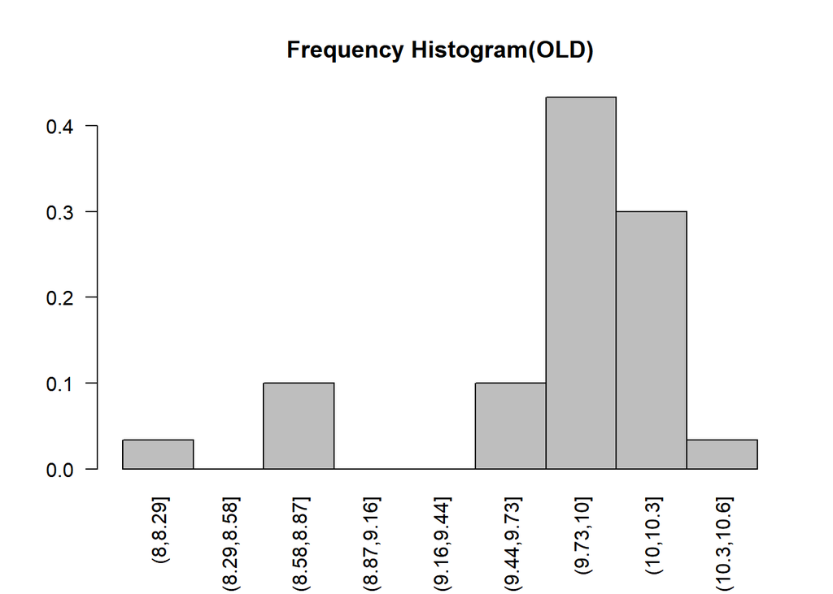

```r
seq(lept, rept,by=inc)->cl
#cl

cvtn<-cut(vtn,breaks=cl)
old.tab=table(cvtn)
old.tab = old.tab/sum(old.tab)
barplot(old.tab,space=0,main="Frequency Histogram(OLD)",las=2)
```

b)

```r
voltage.df=read.csv("C:\\Users\\Luis Mario Trevisi\\OneDrive - University of Oklahoma\\OU\\Applied Statistical Methods\\Math4753\\MATH4753ouTrev0002\\Assignment\\Assignment 1\\VOLTAGE.csv", header=TRUE)
old<-subset(voltage.df,subset=LOCATION=="OLD")
old$VOLTAGE->vtn
stem(vtn)
```

```
##
##   The decimal point is at the |
##
##    8 | 1
##    8 | 778
##    9 |
##    9 | 677888899
##   10 | 0000000011122333
##   10 | 6
```

the relative frequency histogram is more informative because it contains the frequency of the voltage that appears at each range. thus we have a measurement of where voltage reading lies.

```r
voltage.df=read.csv("C:\\Users\\Luis Mario Trevisi\\OneDrive - University of Oklahoma\\OU\\Applied Statistical Methods\\Math4753\\MATH4753ouTrev0002\\Assignment\\Assignment 1\\VOLTAGE.csv", header=TRUE)
new<-subset(voltage.df,subset=LOCATION=="NEW")
new$VOLTAGE->vtn
#vtn
#max(vtn)
#min(vtn)
lept<-min(vtn)-0.05
rept<-max(vtn)+0.05
rnge<-rept-lept
inc<-rnge/9
inc
```

```
## [1] 0.19
```

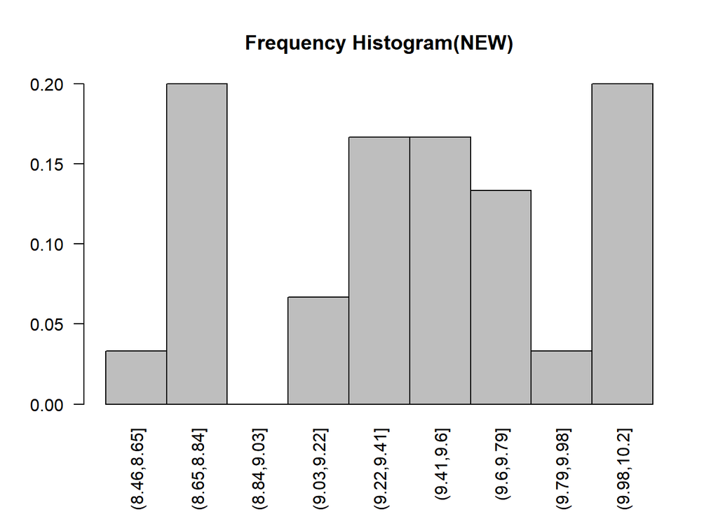

```r
seq(lept, rept,by=inc)->cl
#cl

cvtn<-cut(vtn,breaks=cl)
new.tab=table(cvtn)
new.tab = new.tab/sum(new.tab)
barplot(new.tab,space=0,main="Frequency Histogram(NEW)",las=2)
```

d)

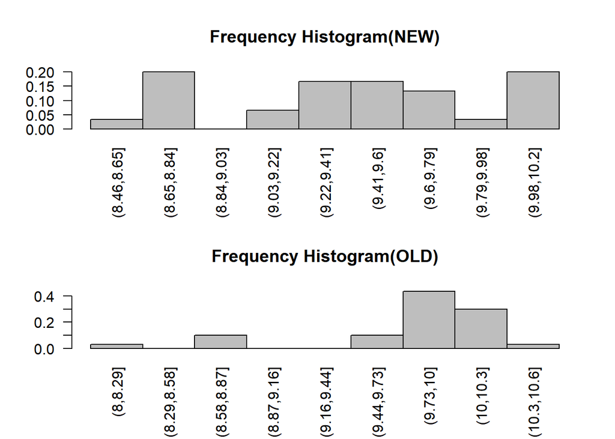

```r
layout(1:2,ncol(2))
barplot(new.tab,space=0,main="Frequency Histogram(NEW)",las=2)
barplot(old.tab,space=0,main="Frequency Histogram(OLD)",las=2)
```

in the old graph we can see that the majority of the measured voltage is higher than the one on the new plot. thus, the new local process is not a good as the one in the remote location

```r
voltage.df=read.csv("C:\\Users\\Luis Mario Trevisi\\OneDrive - University of Oklahoma\\OU\\Applied Statistical Methods\\Math4753\\MATH4753ouTrev0002\\Assignment\\Assignment 1\\VOLTAGE.csv", header=TRUE)
new<-subset(voltage.df,subset=LOCATION=="NEW")
old<-subset(voltage.df,subset=LOCATION=="OLD")
# Create the function.
getmode <- function(v) {
   uniqv <- unique(v)
   uniqv[which.max(tabulate(match(v, uniqv)))]
}
#Mean OlD
mean(old$VOLTAGE)
```

```
## [1] 9.803667
```

```r
#Median OlD
median(old$VOLTAGE)
```

```
## [1] 9.975
```

```r
#Mode OlD
getmode(old$VOLTAGE)
```

```
## [1] 9.98
```

```r
#Mean NEW
mean(new$VOLTAGE)
```

```
## [1] 9.422333
```

```r
#Median NEW
median(new$VOLTAGE)
```

```
## [1] 9.455
```

```r
#Mode NEW
getmode(new$VOLTAGE)
```

```
## [1] 8.82
```

```r
voltage.df=read.csv("C:\\Users\\Luis Mario Trevisi\\OneDrive - University of Oklahoma\\OU\\Applied Statistical Methods\\Math4753\\MATH4753ouTrev0002\\Assignment\\Assignment 1\\VOLTAGE.csv", header=TRUE)

(10.5-mean(old$VOLTAGE))/sd(old$VOLTAGE)
```

```
## [1] 1.287324
```

```r
voltage.df=read.csv("C:\\Users\\Luis Mario Trevisi\\OneDrive - University of Oklahoma\\OU\\Applied Statistical Methods\\Math4753\\MATH4753ouTrev0002\\Assignment\\Assignment 1\\VOLTAGE.csv", header=TRUE)

(10.5-mean(new$VOLTAGE))/sd(new$VOLTAGE)
```

```
## [1] 2.25041
```

8. becaue the z is smaller in the old facility, that means that the voltage of 10.5 is closer to the mean than the mean of the new facility. thus, it is more likely that the voltage of 10.5 would occur on the old facility

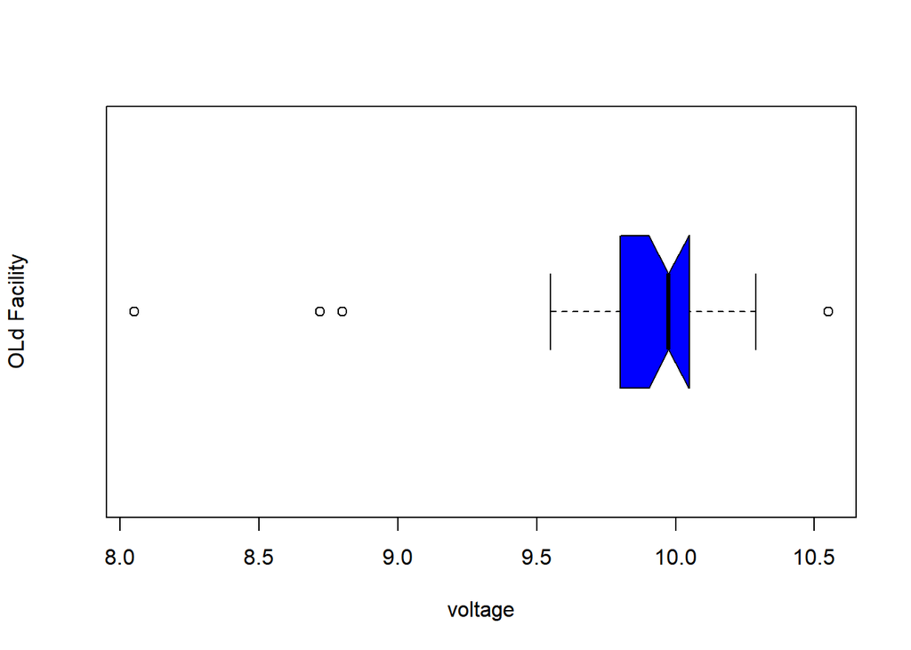

```r
boxplot(old$VOLTAGE,ylab="OLd Facility",xlab= "voltage",col="Blue",notch=TRUE, horizontal =TRUE)
```

yes, there seems to be outliers as there are points which deviate greatly from the data bulk j)

Possible Outliers:

```r
mpg = old$VOLTAGE
z = (mpg-mean(mpg))/sd(mpg)
mpg[abs(z)>=2 & abs(z)<=3]
```

```
## [1] 8.72 8.72
```

Definite Outliers

```r
mpg = old$VOLTAGE
z = (mpg-mean(mpg))/sd(mpg)
mpg[abs(z)>3]
```

```
## [1] 8.05
```

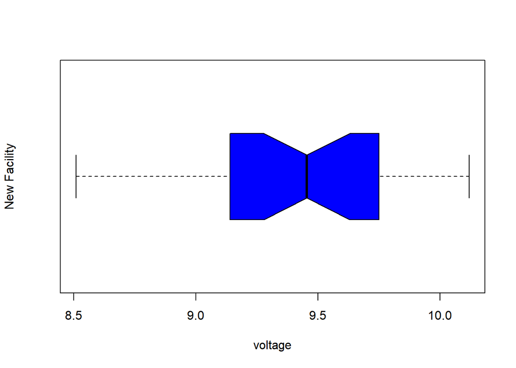

```r
boxplot(new$VOLTAGE,ylab="New Facility",xlab= "voltage",col="Blue",notch=TRUE, horizontal =TRUE)
```

No, i do not detect any outlier in the new data

12. Possible Outliers:

```r
mpg = new$VOLTAGE
z = (mpg-mean(mpg))/sd(mpg)
mpg[abs(z)>=2 & abs(z)<=3]
```

```
## numeric(0)
```

Definite Outliers

```r
mpg = new$VOLTAGE
z = (mpg-mean(mpg))/sd(mpg)
mpg[abs(z)>3]
```

```
## numeric(0)
```

there is no outliers

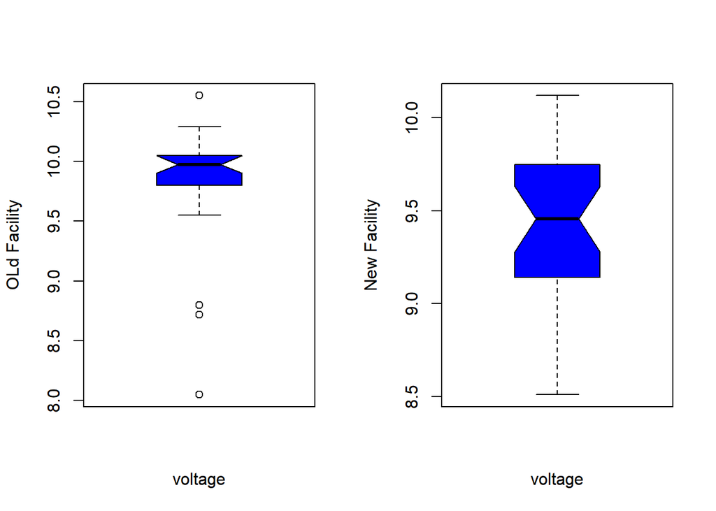

```r
layout(matrix(1:2, nc=2))
boxplot(old$VOLTAGE,ylab="OLd Facility",xlab= "voltage",col="Blue",notch=TRUE)
boxplot(new$VOLTAGE,ylab="New Facility",xlab= "voltage",col="Blue",notch=TRUE)
```

the old facility seems to have the data less spread than the new facility # Task 12

```r
rough.df=read.csv("C:\\Users\\Luis Mario Trevisi\\OneDrive - University of Oklahoma\\OU\\Applied Statistical Methods\\Math4753\\MATH4753ouTrev0002\\Assignment\\Assignment 1\\ROUGHPIPE.csv", header=TRUE)
#head(rough.df)
#Upper bound
mean(rough.df$ROUGH)+2*sd(rough.df$ROUGH)
```

```
## [1] 2.928823
```

```r
#Lower Bound
mean(rough.df$ROUGH)-2*sd(rough.df$ROUGH)
```

```
## [1] 0.8331772
```

# Task 13

```r
ants.df=read.csv("C:\\Users\\Luis Mario Trevisi\\OneDrive - University of Oklahoma\\OU\\Applied Statistical Methods\\Math4753\\MATH4753ouTrev0002\\Assignment\\Assignment 1\\GOBIANTS.csv", header=TRUE)
head(ants.df)
```

```
##   Site      Region Rain Temp PlantCov AntSpecies Diversity
## 1    1  Dry Steppe  196  5.7       40          3      0.89
## 2    2  Dry Steppe  196  5.7       52          3      0.83
## 3    3  Dry Steppe  179  7.0       40         52      1.31
## 4    4  Dry Steppe  197  8.0       43          7      1.48
## 5    5  Dry Steppe  149  8.5       27          5      0.97
## 6    6 Gobi Desert  112 10.7       30         49      0.46
```

```r
ants.df=read.csv("C:\\Users\\Luis Mario Trevisi\\OneDrive - University of Oklahoma\\OU\\Applied Statistical Methods\\Math4753\\MATH4753ouTrev0002\\Assignment\\Assignment 1\\GOBIANTS.csv", header=TRUE)

mean(ants.df$AntSpecies)
```

```
## [1] 12.81818
```

```r
median(ants.df$AntSpecies)
```

```
## [1] 5
```

```r
# Create the function.
getmode <- function(v) {
   uniqv <- unique(v)
   uniqv[which.max(tabulate(match(v, uniqv)))]
}

getmode(ants.df$AntSpecies)
```

```
## [1] 5
```

```r
m = with(ants.df, ants.df[ants.df$Region=="Dry Steppe",])
m
```

```
##   Site     Region Rain Temp PlantCov AntSpecies Diversity
## 1    1 Dry Steppe  196  5.7       40          3      0.89
## 2    2 Dry Steppe  196  5.7       52          3      0.83
## 3    3 Dry Steppe  179  7.0       40         52      1.31
## 4    4 Dry Steppe  197  8.0       43          7      1.48
## 5    5 Dry Steppe  149  8.5       27          5      0.97
```

```r
mean(m$PlantCov)
```

```
## [1] 40.4
```

```r
median(m$PlantCov)
```

```
## [1] 40
```

```r
getmode(m$PlantCov)
```

```
## [1] 40
```

```r
m = with(ants.df, ants.df[ants.df$Region=="Gobi Desert",])
m
```

```
##    Site      Region Rain Temp PlantCov AntSpecies Diversity
## 6     6 Gobi Desert  112 10.7       30         49      0.46
## 7     7 Gobi Desert  125 11.4       16          5      1.23
## 8     8 Gobi Desert   99 10.9       30          4        NA
## 9     9 Gobi Desert  125 11.4       56          4      0.76
## 10   10 Gobi Desert   84 11.4       22          5      1.26
## 11   11 Gobi Desert  115 11.4       14          4      0.69
```

```r
mean(m$PlantCov)
```

```
## [1] 28
```

```r
median(m$PlantCov)
```

```
## [1] 26
```

```r
getmode(m$PlantCov)
```

```
## [1] 30
```

5. Yes, they are different by around 10 units

# Task 14

```r
galaxy.df=read.csv("C:\\Users\\Luis Mario Trevisi\\OneDrive - University of Oklahoma\\OU\\Applied Statistical Methods\\Math4753\\MATH4753ouTrev0002\\Assignment\\Assignment 1\\GALAXY2.csv", header=TRUE)
head(galaxy.df)
```

```
##   VELOCITY
## 1    22922
## 2    20210
## 3    21911
## 4    19225
## 5    18792
## 6    21993
```

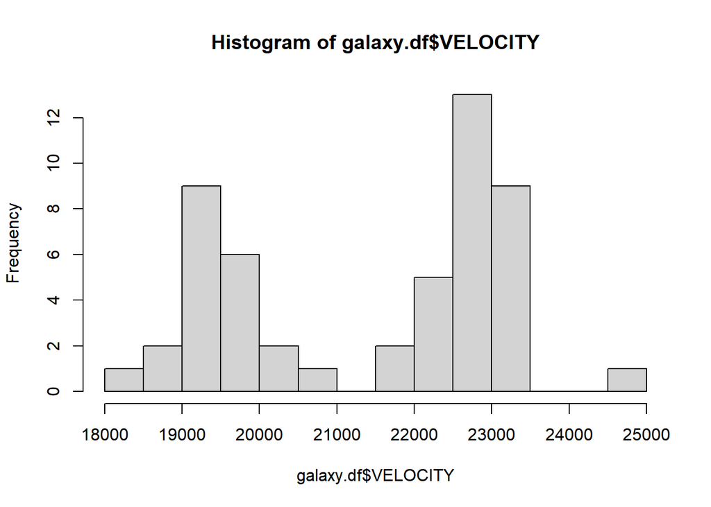

```r
library(lattice)
hist(galaxy.df$VELOCITY, breaks = 10)
```

2. Yes it supports the theory because we can clearly see two modes

```r
A1775A = with(galaxy.df, galaxy.df[galaxy.df$VELOCITY>17999 & galaxy.df$VELOCITY < 21000,])
A1775B = with(galaxy.df, galaxy.df[galaxy.df$VELOCITY>21000 & galaxy.df$VELOCITY < 25000,])
#Mean A1775A
mean(A1775A)
```

```
## [1] 19462.24
```

```r
#Median A1775A
median(A1775A)
```

```
## [1] 19408
```

```r
#Mode A1775A
getmode(A1775A)
```

```
## [1] 20210
```

```r
#Mean A1775B
mean(A1775B)
```

```
## [1] 22838.47
```

```r
#Median A1775B
median(A1775B)
```

```
## [1] 22780
```

```r
#Mode A1775B
getmode(A1775B)
```

```
## [1] 22922
```

4. it is likely to be in A1775A this is because this velocitity is close to the mean velocity of this galaxy (A1775A)

# Task 15

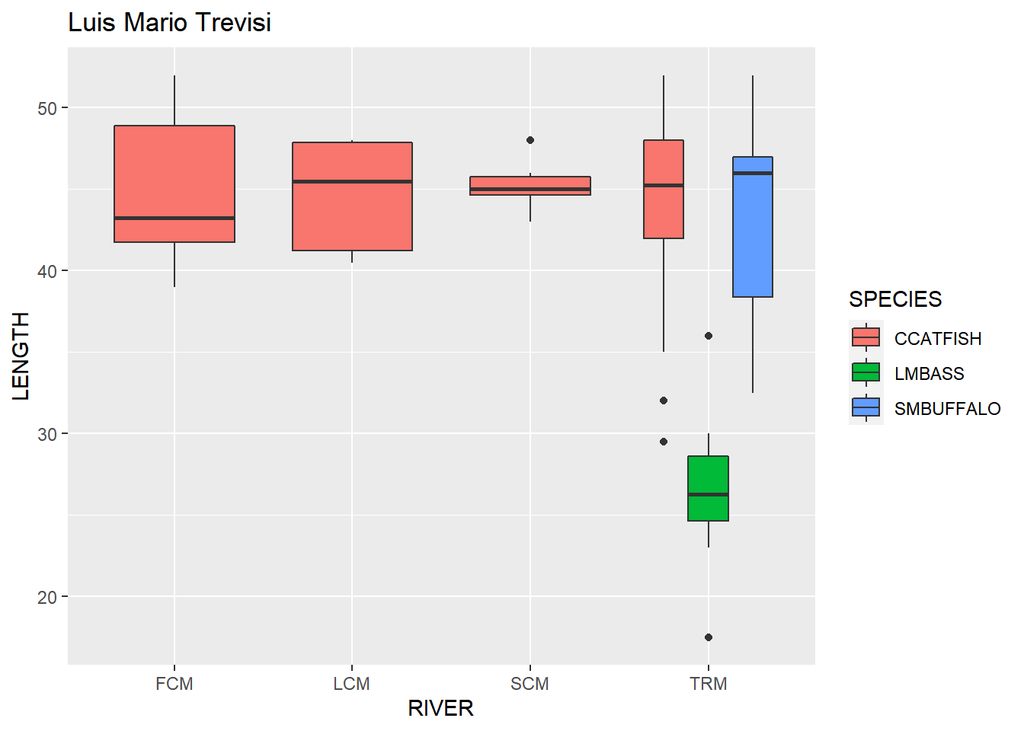

```r
library(ggplot2)
g = ggplot(ddt, aes(x=RIVER, y= LENGTH, fill = SPECIES) )
g = g + geom_boxplot()+ggtitle("Luis Mario Trevisi")
g
```